# Zika Pipeline Status Report

Ensemble filtering and full-text retrieval results

Author

INFLUX Impact

Published

March 23, 2026

## About this report

1. Google News retrieval and cached manifest status
2. Headline ensemble filtering diagnostics using cloud OpenAI (gpt-5-nano) and local DeepSeek (deepseek-r1:14b) models
3. Full-text retrieval status

## Output files directory and status

| artifact | path | exists |
| --- | --- | --- |
| Stage 1 manifest | zika/data/raw/rss/zika_rss_manifest.csv | TRUE |
| Stage 1 normalized RSS | zika/data/intermediate/zika_rss_raw.csv | TRUE |
| Stage 1 daily window analysis | zika/data/intermediate/rss_window_analysis/daily_window_counts.csv | TRUE |
| Stage 1 candidate window summary | zika/data/intermediate/rss_window_analysis/candidate_window_summary.csv | TRUE |
| Stage 2 scored headlines | zika/data/intermediate/zika_headlines_scored.csv | TRUE |
| Stage 2 validation sample | zika/data/validation/zika_headline_validation_sample.csv | TRUE |
| Stage 2 metrics JSON | zika/data/validation/zika_headline_metrics.json | TRUE |
| Stage 3 full text | zika/data/final/zika_fulltext.csv | TRUE |
| Stage 3 failed full text | zika/data/final/zika_fulltext_failed.csv | TRUE |
| Stage 4 BERTopic document topics | zika/data/final/zika_bertopic_document_topics.csv | TRUE |
| Stage 4 BERTopic topic info | zika/data/final/zika_bertopic_topic_info.csv | TRUE |
| Stage 4 BERTopic summary JSON | zika/data/final/zika_bertopic_summary.json | TRUE |
| Stage 4 BERTopic impact document topics | zika/data/final/zika_bertopic_impact_document_topics.csv | TRUE |
| Stage 4 BERTopic impact topic info | zika/data/final/zika_bertopic_impact_topic_info.csv | TRUE |
| Stage 4 BERTopic impact summary JSON | zika/data/final/zika_bertopic_impact_summary.json | TRUE |
| Stage 4 BERTopic impact projection | zika/data/final/zika_bertopic_impact_projection.csv | TRUE |
| Stage 4 BERTopic impact stage timings | zika/data/final/zika_bertopic_impact_stage_timings.csv | TRUE |
| Stage 4 BERTopic comparison CSV | zika/data/final/zika_bertopic_model_comparison.csv | TRUE |
| Stage 4 BERTopic comparison JSON | zika/data/final/zika_bertopic_model_comparison.json | TRUE |
| Stage 4 BERTopic modular analysis CSV | zika/data/final/zika_bertopic_modular_analysis.csv | TRUE |
| Stage 4 BERTopic modular analysis JSON | zika/data/final/zika_bertopic_modular_analysis.json | TRUE |
| Stage 4 BERTopic modular topics CSV | zika/data/final/zika_bertopic_modular_topics.csv | TRUE |
| Stage 4 BERTopic stage timings CSV | zika/data/final/zika_bertopic_stage_timings.csv | TRUE |
| Stage 4 BERTopic topic matches | zika/data/final/zika_bertopic_topic_matches.csv | TRUE |

## Step 1 Retrieval

**Note**

The manifest currently spans 2010-01-01 to 2025-12-31.

Stage 1 is implemented with a two-step workflow:

1. **Network retrieval** builds daily Google News search windows, checks the manifest, queries only unfinished windows, and writes one cached JSON payload per window.
2. **Parsing and normalization** re-reads cached payloads with `status %in% c("success", "empty")`, flattens the feed entries into a table, and applies deterministic deduplication before writing the final CSV and Parquet outputs.

The retrieval script is therefore optimized for interruption and restart, while the parsing script is optimized for fast reruns from cache.

### How the retrieval step works

1. Build daily windows from the configured query period.
2. Use the manifest as the authoritative checkpoint to decide whether a window is already complete, due for retry, or still pending.
3. Query Google News using the English / US edition configuration and persist the raw JSON payload to `zika/data/raw/rss/`.
4. Detect throttling from HTTP status and Google “Sorry” pages, then stop early instead of continuing to hammer adjacent windows.
5. Update the manifest after each attempt with timestamps, attempt counts, HTTP status, cache path, and error summary.
6. Parse only cached `success` and `empty` windows into a flat table.
7. Apply deterministic deduplication before writing the final Stage 1 CSV and Parquet outputs.

### Should daily windows stay daily?

**Important**

The archived Zika RSS cache suggests that **daily windows are safer than necessary for most days, but broader windows should still be kept modest**.

Across **5,844** observed `1-day` windows, the archive averaged **3.95** items per day with a median of **2**. However, **7** days already reached `100` items, which likely reflects the practical Google News RSS ceiling on high-volume dates.

The best compromise from the retrospective simulation is **3-day windows**. That setting would reduce requests by about **66.7%** while keeping estimated cap-risk at **1.0%**. In contrast, `7-day` windows push cap-risk high enough to warrant caution, and `14-day+` windows look too aggressive for reliable historical retrieval.

**Note**

For the `3-day` candidate, the archive contains **58** rolling windows where the summed daily counts exceed `100`. These windows are then grouped into **12** broader covered spans when they overlap in calendar time.

The **balance strategy** would be `3-day -> 1-day -> back to 3-day` retrieval logic, where the pipeline defaults to 3-day windows but falls back to daily windows if a 3-day window contains more than 100 items in the archive. This would allow for more efficient retrieval during quieter periods while still respecting the observed limits on busier days.

A hierarchical windows of `30-day -> 14-day-> 7-day -> 3-day -> 1-day` can even be used!!!

| metric | value |
| --- | --- |
| observed_daily_windows | 5844.00 |
| mean_items_per_day | 3.95 |
| median_items_per_day | 2.00 |
| p90_items_per_day | 9.00 |
| p99_items_per_day | 35.00 |
| max_items_per_day | 100.00 |
| days_ge_20_items | 156.00 |
| days_ge_50_items | 31.00 |
| days_ge_80_items | 14.00 |
| days_ge_100_items | 7.00 |

| window_days | requests_if_used | request_reduction | average_total | p90_total | max_total | near_cap_share | cap_share | recommendation |
| --- | --- | --- | --- | --- | --- | --- | --- | --- |
| 1 | 5844 | 0.0% | 3.95 | 9 | 100 | 0.2% | 0.1% | recommended |
| 3 | 1948 | 66.7% | 11.85 | 25 | 300 | 1.7% | 1.0% | recommended |
| 7 | 835 | 85.7% | 27.66 | 51 | 636 | 4.7% | 4.3% | use_with_caution |
| 14 | 418 | 92.8% | 55.32 | 100 | 1224 | 19.0% | 10.2% | not_recommended |
| 30 | 195 | 96.7% | 118.54 | 211 | 1989 | 55.4% | 46.7% | not_recommended |

| period_id | period_start | period_end | days_covered | windows_gt_100 | peak_total_items |
| --- | --- | --- | --- | --- | --- |
| 1 | 2016-01-20 | 2016-02-20 | 32 | 26 | 300 |
| 2 | 2016-02-22 | 2016-02-26 | 5 | 3 | 144 |
| 3 | 2016-02-29 | 2016-03-05 | 6 | 4 | 130 |
| 4 | 2016-03-29 | 2016-03-31 | 3 | 1 | 106 |
| 5 | 2016-04-10 | 2016-04-15 | 6 | 4 | 201 |
| 6 | 2016-05-09 | 2016-05-12 | 4 | 2 | 105 |
| 7 | 2016-06-06 | 2016-06-09 | 4 | 2 | 107 |
| 8 | 2016-06-27 | 2016-06-30 | 4 | 2 | 122 |
| 9 | 2016-07-31 | 2016-08-05 | 6 | 4 | 172 |
| 10 | 2016-08-07 | 2016-08-11 | 5 | 3 | 120 |
| 11 | 2016-08-22 | 2016-08-26 | 5 | 3 | 143 |
| 12 | 2016-08-28 | 2016-09-02 | 6 | 4 | 141 |

**Important**

The latest completed **network retrieval** run in the logs took **2h 03m 18s** for **5,844** configured daily windows.  
The latest completed **parse + deduplication** pass took **5s**.

In practice, retrieval is the dominant cost. Parsing cached payloads is fast and stayed in the order of seconds on the latest run.

### Detailed metrics and logs

| indicator | value | meaning |
| --- | --- | --- |
| manifest_rows | 5844 | One row per retrieval window tracked in the resumable manifest. |
| successful_windows | 3720 | Windows whose cached payload contains at least one RSS item. |
| empty_windows | 2124 | Windows fetched successfully but returning zero RSS items for the query. |
| failed_or_throttled_windows | 0 | Windows left unfinished because the last observed attempt failed or was throttled. |
| cached_payloads_present | 5844 | Manifest rows with a cached JSON payload on disk. |
| completed_windows (log) | NA | Windows already complete at the time of a retrieval run, including reused cached windows from earlier runs. |
| success_fetches (log) | NA | Newly fetched windows with one or more entries during that specific retrieval invocation. |
| empty_fetches (log) | NA | Newly fetched windows with zero entries during that invocation. |
| cached_reused (log) | NA | Previously completed windows skipped during the invocation because the cache and manifest state were already valid. |
| parsed_rows | NA | Rows extracted from cached payloads before deduplication. |
| deduped_rows | NA | Rows retained after deterministic deduplication by redirect URL, GUID, and title+pubdate fallback. |

## Step 2 Ensemble Filtering

**Warning**

- Step 1 retrieved total 12,194 headlines.
- The ensemble filtering stage was conducted on a sample of about **2406 headlines** (2018-2020)

| metric | value |
| --- | --- |
| headline_rows | 2406 |
| completed_rows | 2195 |
| incomplete_rows | 211 |
| openai_error_rows | 211 |
| local_error_rows | 0 |

|  | field | error | count |
| --- | --- | --- | --- |
| 0 | openai_error | parse_error:invalid_json | 205 |
| 1 | openai_error | {"message": "Could not finish the message beca... | 6 |

**Caution**

While local model was able to process all 2406 headlines without error, the OpenAI batch encountered errors on 211 rows.

The error was: {“message”: “Could not finish the message because max_tokens or model output limit was reached. Please try again with higher max_tokens.”, “type”: “invalid_request_error”, “param”: null, “code”: null}. **Current max_tokens: 800**

| model | label | rows | share_within_model |
| --- | --- | --- | --- |
| OpenAI | irrelevant | 1289 | 58.7% |
| OpenAI | relevant | 693 | 31.6% |
| OpenAI | unsure | 213 | 9.7% |
| Local | irrelevant | 1065 | 48.5% |
| Local | relevant | 808 | 36.8% |
| Local | unsure | 322 | 14.7% |

| metric | value |
| --- | --- |
| paired_rows | 2195 |
| agreement_rows | 1812 |
| disagreement_rows | 383 |
| agreement_rate | 82.6% |

Among the sample of **2,195** rows, there are **1812** rows where both models agree on the same label:

- both models called **irrelevant** on **1022** rows (**46.6%** rows can be completely drop)
- both models called **relevant** on **686** rows (**31.3%** of the total sample)
- both models called **unsure** on **104** rows (**4.7%** of all paired rows)

**Decision rule**

- `drop` if `OpenAI = irrelevant`and `local = irrelevant` **(n=1022/1022)**.
- `keep` if `OpenAI = relevant` and `local = relevant` and rationale_similarity >= 0.75. `rationale_similarity` is only computed when both models said relevant. It uses SBERT cosine similarity on the two rationales. Otherwise it is left as not applicable **(n=614/686)**.
- `review` for everything else. That means review covers:
  - any disagreement between models, **(n=383)**
  - any case where either model says unsure **(n=104)**
  - both say relevant but the rationale similarity is below threshold **(n=72/686, with most rationale similarities above 0.7 and just below 0.75)**.
  - both say relevant but similarity could not be computed **(n=0)**

| final_action | rows |
| --- | --- |
| drop | 1022 |
| keep | 614 |
| review | 559 |

**Note**

Run ensemble filtering left 559 rows, about 1/4 headlines to be reviewed by human. It is important to understand the differences in how the two models approach label assignment.

### OpenAI-by-local label cross-tabulation

| openai_label | deepseek-r1:14b relevant | deepseek-r1:14b irrelevant | deepseek-r1:14b unsure |
| --- | --- | --- | --- |
| relevant | 686 | 4 | 3 |
| irrelevant | 52 | 1022 | 215 |
| unsure | 70 | 39 | 104 |

Within each OpenAI label, how the local model redistributed the same rows. Each row sums to 100%.

| openai_label | deepseek-r1:14b relevant | deepseek-r1:14b irrelevant | deepseek-r1:14b unsure |
| --- | --- | --- | --- |
| relevant | 99.0% | 0.6% | 0.4% |
| irrelevant | 4.0% | 79.3% | 16.7% |
| unsure | 32.9% | 18.3% | 48.8% |

It is clearly seen that when OpenAI says `irrelevant`, the local model is often reluctant (just small percent-4% think that it is relevant). Instead, when OpenAI says `unsure`, the local model is only agree on 48.8% of the time, while the big difference is it thinks 32.9% of the case is `relevant`.

Investigating further showed that OpenAI tends to require a more explicit Zika signal in the headline, whereas the local model more often treats broader vector, surveillance, or outbreak context as relevant. Some examples where OpenAI==`irrelevant` but local==`relevant`|`unsure`:

- [New Mosquito Virus Identified in Humans for the First Time Ever Dr. Axe](https://draxe.com/health/keystone-virus/)
- Enabling Research in Low-Income Settings During Disease Outbreaks: Implementing, Learning and Preparing University of Oxford
- [Art and science and serendipity DePauw University](https://www.depauw.edu/stories/details/art-and-science-and-serendipity/)
- [““Helpless Means You Can’t Do Anything. There’s a Lot We Can Do.”” Spiegel](https://www.spiegel.de/international/world/anthony-fauci-helpless-means-you-can-t-do-anyting-there-s-a-lot-we-can-do-a-211cdaf5-d0b1-41f4-b62c-25b76f4d8828)

### Step 2 Runtime

| component | metric | value |
| --- | --- | --- |
| OpenAI batch (latest successful run) | submitted_rows | 2406 |
| OpenAI batch (latest successful run) | hydrated_rows | 2195 |
| OpenAI batch (latest successful run) | error_rows | 211 |
| OpenAI batch (latest successful run) | turnaround_time | 12m 46s |
| Local model scoring | local_scoring_sessions | 5 |
| Local model scoring | final_local_rows | 2406 |
| Local model scoring | cumulative_active_scoring_time | 26h 39m 58s |
| Local model scoring | approx_rows_per_hour | 90.2 |
| Local model scoring | approx_seconds_per_row | 39.9 |

- **OpenAI batch turnaround** measures elapsed time from batch submission to successful hydration of results back into the local pipeline outputs.
- **Local model runtime** measures active scoring time observed in the log across resumable Stage 2 sessions.

For the current run history, the latest successful OpenAI batch turnaround was **12m 46s**, while the local model required **26h 39m 58s** of active scoring time across **5** resumed sessions. The time needed for openAI batch is not correct and usually longer (batching often requires 24h to return outputs).

## Validation Assets

This section uses Kate’s file at `zika/data/validation/zika_headline_validation_sample_full.csv` as an external reference set. The comparison is done on the intersection between the two datasets rather than on all rows. The comparison workflow is:

1. Parse and normalize Kate’s file.
2. Keep only Kate rows with parseable publication dates between 2018 and 2020.
3. Match Kate rows to our experimental output using normalized Google News redirect URLs.
4. Compare Kate `RelevantYN` against our `final_action`.

| metric | value |
| --- | --- |
| kate_rows_total | 4697 |
| kate_rows_2018_2020_with_parseable_date | 630 |
| stage2_completed_rows | 2195 |
| matched_common_rows | 221 |
| matched_rows_in_review | 55 |
| strict_evaluable_rows | 166 |

For the current data:

- Kate’s file imports as **4697** rows
- only **630** rows have parseable publication dates between 2018 and 2020
- the normalized URL join yields **221** common rows
- of those, **55** marked as to be `reviewed`
- the cross evaluation is therefore uses **166** rows

| Kate_RelevantYN | Ensemble filtering results drop | Ensemble filtering results keep | Ensemble filtering results review |
| --- | --- | --- | --- |
| No | 40 | 1 | 3 |
| Yes | 75 | 50 | 52 |

On that strict matched subset, the current ensemble action achieves:

- **accuracy = 0.542**
- **precision = 0.98**
- **recall = 0.4**
- **F1 = 0.568**

## Step 3 Full Text Retrieval

Latest substantive Step 3 retrieval run derived from the full-text log.

| metric | value |
| --- | --- |
| kept_urls_at_start | 614 |
| pending_urls | 614 |
| new_success | 495 |
| new_failed | 119 |
| elapsed_time | 46m 17s |
| approx_urls_per_minute | 13.3 |

For the current artifacts on disk, the latest substantive Step 3 run started with **614** kept URLs and **614** pending fetches. It completed in **46m 17s**, producing **495** new successful extractions and **119** failed fetches. That corresponds to an observed throughput of about **13.3** processed URLs per minute for the most recent real retrieval pass.

### Why some full-text retrievals failed

Step 3 failures are expected in a web-scale article-retrieval pipeline because the script is operating against publisher websites with heterogeneous access controls and HTML structures. A failed row does **not** necessarily mean that the URL resolution step failed; it often means the target publisher blocked automated access, returned too little extractable article text, or timed out before the extractor could finish.

Step 3 full-text failure groups derived from the failed-output table.

| failure_group | rows | share_of_failed_rows |
| --- | --- | --- |
| publisher_blocked_http_403 | 89 | 74.8% |
| insufficient_extractable_text | 15 | 12.6% |
| network_timeout | 9 | 7.6% |
| other_http_error | 5 | 4.2% |
| ssl_or_certificate_error | 1 | 0.8% |

Top domains represented in the failed full-text rows.

| failure_domain | failed_rows |
| --- | --- |
| telegraph.co.uk | 8 |
| medicalxpress.com | 7 |
| nejm.org | 6 |
| pnas.org | 6 |
| science.org | 6 |
| contagionlive.com | 5 |
| nytimes.com | 4 |
| thelancet.com | 4 |
| washingtonpost.com | 4 |
| nation.africa | 3 |

For the current failed-output file:

- **89 of 119** failed rows are direct **HTTP 403** responses, which indicates that the target publisher accepted the request but refused to serve the article content to the scraper.
- **15** rows resolved successfully but produced either too little article text or no usable extraction output after the fallback extractors ran.
- **9** rows failed because the destination site timed out before the page could be fetched, and **1** row failed because of an SSL certificate verification problem.

The main interpretation is that Step 3 is constrained more by **publisher access control and network variability** than by the extraction code itself. In the current run, the single biggest source of failure is publisher blocking via HTTP 403, while the next tier of failures comes from pages that either timed out or yielded text that was too short to count as a usable article body.

## Step 4 BERTopic on the retrieved full-text subset

To explore whether the retained full-text corpus contains coherent thematic structure beyond the headline labels, I first ran a standard BERTopic pipeline over the successful Stage 3 subset and then added an **impact-guided** BERTopic refinement. The modeling input is intentionally narrower than the raw `zika_fulltext.csv` table: the script keeps documents with non-empty text, enforces a minimum word-count threshold, applies a lightweight English-language filter, and truncates each document to a fixed word budget before embedding.

That refinement matters for interpretation. The fully unsupervised MiniLM baseline tended to collapse the retained corpus into very broad Zika-centered clusters, which is not especially useful when the research goal is to characterize **impact pathways**. The new impact-guided run therefore suppresses generic Zika vocabulary, seeds BERTopic with impact-oriented concept bundles, and uses a KMeans partition to force a more inspectable thematic split.

Following BERTopic’s modular design, the current report now treats the pipeline as six separate submodels:

1. embeddings
2. dimensionality reduction
3. clustering
4. vectorization
5. c-TF-IDF weighting
6. representation modeling

The generic `zika_bertopic_*` outputs correspond to the current **baseline** embedding backend, which remains `all-MiniLM-L6-v2`. The richer modular outputs are stored separately in `zika_bertopic_modular_analysis.*`, `zika_bertopic_modular_topics.csv`, and `zika_bertopic_stage_timings.csv`. The new impact-guided outputs are written to `zika_bertopic_impact_*`.

Impact-guided BERTopic run summary for the current full-text subset.

| metric | value |
| --- | --- |
| documents_input | 496 |
| documents_modeled | 488 |
| documents_excluded | 8 |
| unique_topics_excluding_outlier | 8 |
| outlier_documents | 0 |
| embedding_seconds | 5.255 |
| bertopic_fit_seconds | 1.324 |
| projection_seconds | 0.348 |
| runtime_human | 7s |

BERTopic submodels used in the current analysis and the explicit ablations added for this report.

| pipeline_step | baseline_choice | analysis_added_in_report |
| --- | --- | --- |
| 1. Embeddings | all-MiniLM-L6-v2 and BAAI/bge-base-en-v1.5 | Compare MiniLM versus BGE on the same filtered corpus. |
| 2. Dimensionality reduction | UMAP (n_neighbors = 15, n_components = 5, min_dist = 0, cosine metric) | Compare UMAP against PCA while holding the primary embedding fixed. |
| 3. Clustering | HDBSCAN (min_cluster_size = 12, eom) | Compare HDBSCAN against KMeans while reusing the same MiniLM embeddings. |
| 4. Vectorizer | CountVectorizer with English stop words, min_df = 2, ngrams = 1:2 | Compare basic unigram versus tuned bigram CountVectorizer on fixed topic assignments. |
| 5. c-TF-IDF | ClassTfidfTransformer(reduce_frequent_words = TRUE) | Compare standard, reduce-frequent, and BM25-plus-reduce-frequent weighting. |
| 6. Representation model | KeyBERTInspired | Compare c-TF-IDF only, KeyBERTInspired, and MMR representations. |

### Impact-guided topic structure

Impact-guided BERTopic topics after removing generic Zika vocabulary and seeding the model with impact-oriented concept bundles.

| topic_id | impact_label | document_count | share of modeled docs | top_terms |
| --- | --- | --- | --- | --- |
| 0 | Vaccines and therapeutics | 122 | 25.0% | antiviral \| proteins \| antibodies \| membrane \| flavivirus \| vaccines \| ns1 \| rna \| mice \| dengue |
| 1 | Congenital outcomes and child risk | 100 | 20.5% | microcephaly \| children \| brazil \| risk \| birth defects \| congenital \| cdc \| problems \| pregnant \| developmental |
| 2 | Congenital outcomes and child risk | 72 | 14.8% | pregnancy \| microcephaly \| congenital \| neural \| development \| stem cells \| fetuses \| mice \| macaques \| neural stem |
| 3 | Vector ecology and climate risk | 49 | 10.0% | ae \| vector \| risk \| climate change \| fever \| mosquito species \| aedes albopictus \| dengue \| south america \| public health |
| 4 | Travel advisories and regional surveillance | 47 | 9.6% | caribbean \| cdc \| risk \| cuba \| travelers \| cases \| pregnant \| public health \| islands \| surveillance |
| 5 | Congenital outcomes and child risk | 46 | 9.4% | symptoms \| dengue \| rajasthan \| cdc \| testing \| risk \| pregnant women \| rash \| repellents \| microcephaly |
| 6 | Diagnostics and laboratory surveillance | 34 | 7.0% | mosquitoes \| assay \| pcr \| diagnostic \| technology \| cost \| blood supply \| urine \| samples \| aegypti |
| 7 | Sexual and reproductive transmission | 18 | 3.7% | semen \| reproductive \| testis \| sexually transmitted \| immune \| dpi \| intravaginal \| rna \| persist \| epithelial cells |

Runtime required for the impact-guided BERTopic analysis.

| stage_name | runtime_seconds | runtime_human |
| --- | --- | --- |
| Embedding | 5.255 | 5s |
| BERTopic fit | 1.324 | 1s |
| 2D projection | 0.348 | 0s |

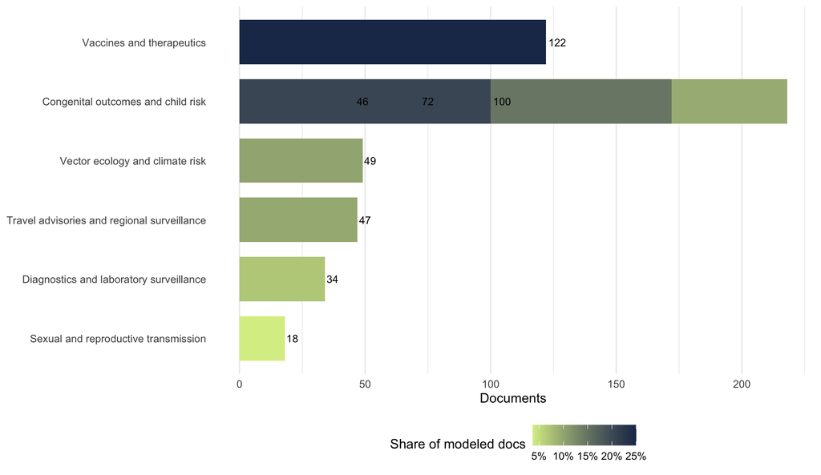

Figure 1: Document counts by impact-guided BERTopic topic. This view is intended to show which impact pathways dominate the retained full-text corpus.

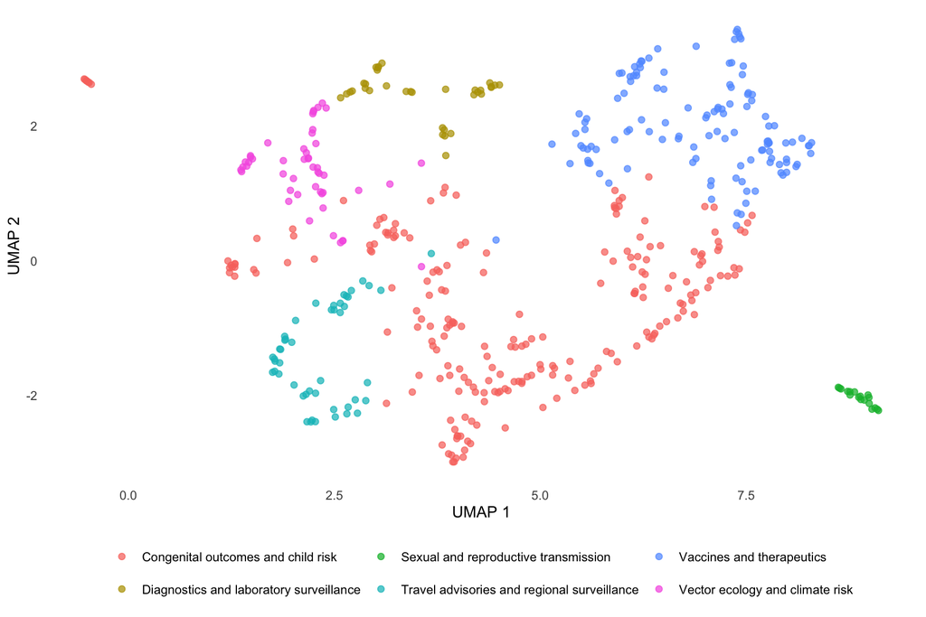

Figure 2: Two-dimensional UMAP projection of the impact-guided BERTopic assignments. Nearby points have similar embeddings; color indicates the impact theme assigned by BERTopic.

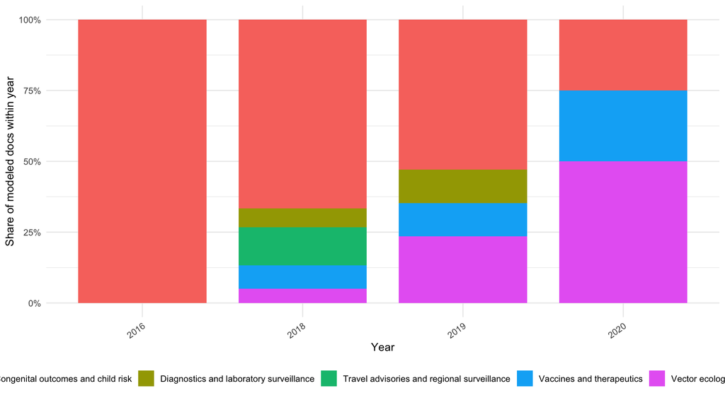

Figure 3: Year-by-year topic mix in the impact-guided BERTopic run. Within each year, the stacked bars show the share of documents allocated to each impact theme.

Representative headlines from the impact-guided BERTopic topics. Within each topic, examples are the longest modeled documents in the retained full-text subset.

| impact_label | year | headline | domain | words |
| --- | --- | --- | --- | --- |
| Congenital outcomes and child risk | NA | Brain Malformations in Zika Virus Related Congenital Microcephaly: interactions among clinical and imaging scores and a semi-automated classification of severity based on MRI indices (RaRe - Radiologi… | www.medrxiv.org | 831 |
| Congenital outcomes and child risk | 2018 | Update: Noncongenital Zika Virus Disease Cases — 50 U.S. States and the District of Columbia, 2016 - Centers for Disease Control and Prevention \| CDC (.gov) | www.cdc.gov | 826 |
| Congenital outcomes and child risk | NA | Zika virus symptoms, treatment, travel risks, birth defects: What pregnant women and others need to know about this frightening disease - CBS News | www.cbsnews.com | 823 |
| Diagnostics and laboratory surveillance | NA | Development and Validation of Reverse Transcription Loop-Mediated Isothermal Amplification (RT-LAMP) for Rapid Detection of ZIKV in Mosquito Samples from Brazil - Nature | www.nature.com | 822 |
| Diagnostics and laboratory surveillance | NA | Simpler, Faster, and Sensitive Zika Virus Assay Using Smartphone Detection of Loop-mediated Isothermal Amplification on Paper Microfluidic Chips - Nature | www.nature.com | 820 |
| Diagnostics and laboratory surveillance | NA | Synthetic biology mosquitoes: Pioneering solution emerges to counter fears over using genetic engineering to control Zika - Genetic Literacy Project | geneticliteracyproject.org | 820 |
| Sexual and reproductive transmission | NA | Immunoprofiles of human Sertoli cells infected with Zika virus reveals unique insights into host-pathogen crosstalk - Nature | www.nature.com | 817 |
| Sexual and reproductive transmission | NA | Low expression of RNA sensors impacts Zika virus infection in the lower female reproductive tract - Nature | www.nature.com | 817 |
| Sexual and reproductive transmission | NA | The Dual Role of the Immune Response in Reproductive Organs During Zika Virus Infection - Frontiers | www.frontiersin.org | 816 |
| Travel advisories and regional surveillance | NA | UNC, RTI International researchers assess US travelers’ knowledge of Zika virus, willingness to take hypothetical vaccine - UNC Gillings School of Global Public Health | sph.unc.edu | 824 |
| Travel advisories and regional surveillance | NA | Floridians Took Zika Virus More Seriously Than Rest of U.S., But Most Did Nothing - Annenberg Public Policy Center | www.annenbergpublicpolicycenter.org | 819 |
| Travel advisories and regional surveillance | NA | Turks and Caicos Premier says nation ‘elated’ over removal from Zika list; praises CARPHA and CARICOM - magneticmediatv.com | magneticmediatv.com | 818 |
| Vaccines and therapeutics | NA | A New In Vivo Model to Study Protective Immunity to Zika Virus Infection in Mice With Intact Type I Interferon Signaling - Frontiers | www.frontiersin.org | 823 |
| Vaccines and therapeutics | NA | A Vaccine Based on a Modified Vaccinia Virus Ankara Vector Expressing Zika Virus Structural Proteins Controls Zika Virus Replication in Mice - Nature | www.nature.com | 823 |
| Vaccines and therapeutics | NA | Extract from Aphloia theiformis , an edible indigenous plant from Reunion Island, impairs Zika virus attachment to the host cell surface - Nature | www.nature.com | 823 |
| Vector ecology and climate risk | 2019 | Mosquitoes that transmit the Zika virus and dengue fever may have access to 1 billion more people in the years ahead - Business Insider | www.businessinsider.com | 824 |
| Vector ecology and climate risk | NA | Vector competence of Aedes aegypti and Culex quinquefasciatus from the metropolitan area of Guadalajara, Jalisco, Mexico for Zika virus - Nature | www.nature.com | 821 |
| Vector ecology and climate risk | NA | Future increase in extreme El Nino events under greenhouse warming increases Zika virus incidence in South America - Nature | www.nature.com | 819 |

Measured runtime by BERTopic analysis. Dimensionality-reduction and clustering baselines include the MiniLM embedding pass; later lexical ablations time only `update_topics()`.

| analysis_group | analysis_variant | stage_name | runtime_seconds | runtime_human |
| --- | --- | --- | --- | --- |
| dimensionality_reduction | pca | bertopic_fit_transform | 0.434 | 0s |
| dimensionality_reduction | pca | embedding_encode | 0.000 | 0s |
| dimensionality_reduction | umap | bertopic_fit_transform | 2.995 | 3s |
| dimensionality_reduction | umap | embedding_encode | 5.255 | 5s |
| clustering | hdbscan | bertopic_fit_transform | 2.995 | 3s |
| clustering | hdbscan | embedding_encode | 5.255 | 5s |
| clustering | kmeans | bertopic_fit_transform | 0.970 | 1s |
| clustering | kmeans | embedding_encode | 0.000 | 0s |
| vectorizer | basic_unigram | update_topics | 0.274 | 0s |
| vectorizer | tuned_bigram | update_topics | 0.368 | 0s |
| ctfidf | bm25_reduce_frequent | update_topics | 0.321 | 0s |
| ctfidf | reduce_frequent | update_topics | 0.334 | 0s |
| ctfidf | standard | update_topics | 0.370 | 0s |
| representation | ctfidf_only | update_topics | 0.132 | 0s |
| representation | keybert_inspired | update_topics | 0.325 | 0s |
| representation | mmr_diverse | update_topics | 0.319 | 0s |

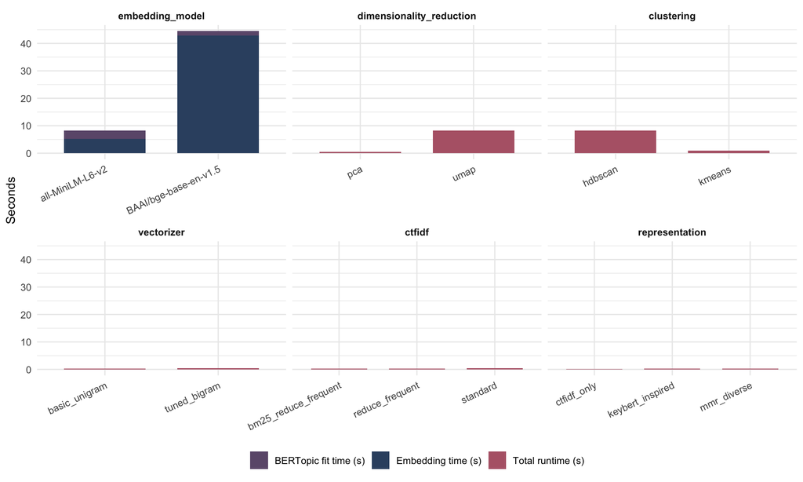

Runtime required for each BERTopic analysis. Embedding comparisons are split into encoding and BERTopic fit time; later module ablations reuse cached MiniLM embeddings.

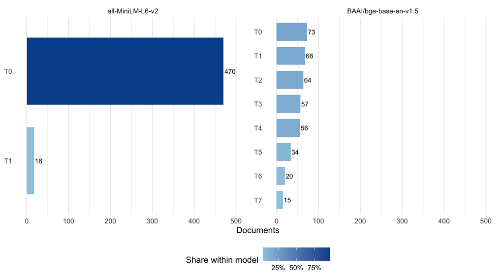

Topic-size structure under each embedding backend. MiniLM yields a highly concentrated solution, while BGE splits the corpus into more subtopics.

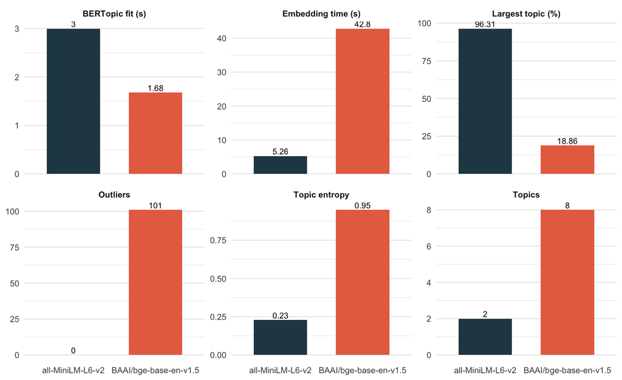

Model-level BERTopic comparison across MiniLM and BGE on the same filtered full-text subset.

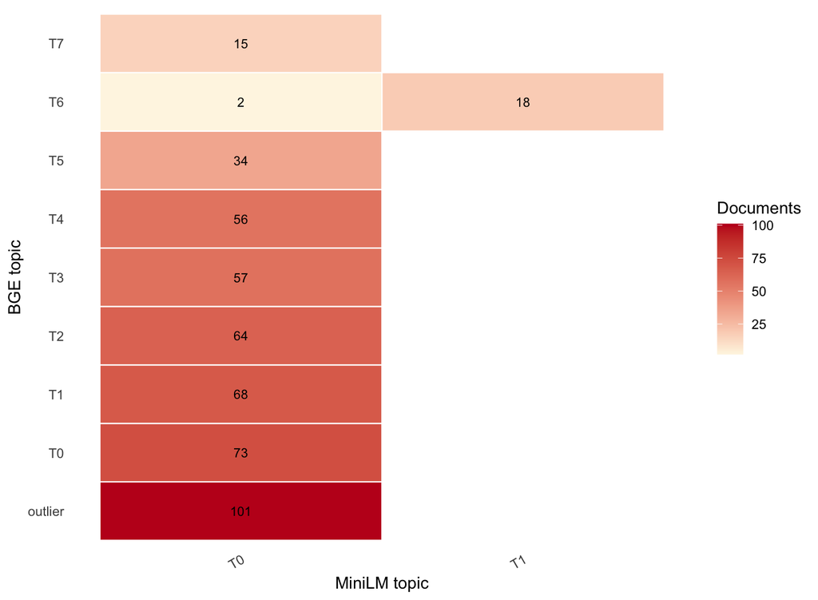

Document-level reassignment from MiniLM topics to BGE topics. Darker cells indicate more documents following that path.

Primary BERTopic topic summary. Topic `-1` would indicate outliers; none were produced in the current MiniLM run.

| topic_id | document_count | topic_name | top_terms |
| --- | --- | --- | --- |
| 0 | 470 | 0_zika virus_zika_virus zikv_zikv infection | zika virus \| zika \| virus zikv \| zikv infection \| dengue \| mosquito \| virus infection \| mosquitoes \| vaccine \| viral |
| 1 | 18 | 1_zika virus_infectious zika_zika_transmission zika | zika virus \| infectious zika \| zika \| transmission zika \| zika rna \| zikv infection \| virus zikv \| infectious virus \| zikv rna \| antiviral |

Document share by BERTopic topic in the modeled subset.

| topic_id | topic_name | documents | share_of_modeled_docs |
| --- | --- | --- | --- |
| 0 | 0_zika virus_zika_virus zikv_zikv infection | 470 | 96.3% |
| 1 | 1_zika virus_infectious zika_zika_transmission zika | 18 | 3.7% |

Per-model BERTopic comparison using the same filtered corpus.

| embedding_model | documents_modeled | unique_topics_excluding_outlier | outlier_documents | largest_topic_count | largest_topic_share | normalized_topic_entropy | mean_topic_ctfidf_cosine | max_topic_ctfidf_cosine | unique_representation_terms | runtime_seconds | runtime_human | embedding_seconds | analysis_seconds |
| --- | --- | --- | --- | --- | --- | --- | --- | --- | --- | --- | --- | --- | --- |
| BAAI/bge-base-en-v1.5 | 488 | 8 | 101 | 73 | 18.9% | 0.949 | 0.440 | 0.625 | 47 | 44.475 | 44 | 42.797 | 1.677 |
| all-MiniLM-L6-v2 | 488 | 2 | 0 | 470 | 96.3% | 0.228 | 0.819 | 0.819 | 16 | 8.251 | 8 | 5.255 | 2.995 |

Summary of the modular BERTopic analyses on the primary MiniLM embedding run.

| analysis_group | analysis_variant | runtime_seconds | topics | outliers | largest topic (%) | topic entropy | mean c-TF-IDF cosine | unique representation terms |
| --- | --- | --- | --- | --- | --- | --- | --- | --- |
| dimensionality_reduction | pca | 0.434 | 2 | 306 | 72.5 | 0.848 | 0.662 | 20 |
| dimensionality_reduction | umap | 8.251 | 2 | 0 | 96.3 | 0.228 | 0.819 | 16 |
| clustering | kmeans | 0.970 | 6 | 0 | 25.2 | 0.944 | 0.528 | 41 |
| clustering | hdbscan | 8.251 | 2 | 0 | 96.3 | 0.228 | 0.819 | 16 |
| vectorizer | basic_unigram | 0.274 | 2 | 0 | 96.3 | 0.228 | 0.587 | 18 |
| vectorizer | tuned_bigram | 0.368 | 2 | 0 | 96.3 | 0.228 | 0.819 | 15 |
| ctfidf | bm25_reduce_frequent | 0.321 | 2 | 0 | 96.3 | 0.228 | 0.820 | 15 |
| ctfidf | reduce_frequent | 0.334 | 2 | 0 | 96.3 | 0.228 | 0.819 | 15 |
| ctfidf | standard | 0.370 | 2 | 0 | 96.3 | 0.228 | 0.670 | 16 |
| representation | ctfidf_only | 0.132 | 2 | 0 | 96.3 | 0.228 | 0.819 | 18 |
| representation | mmr_diverse | 0.319 | 2 | 0 | 96.3 | 0.228 | 0.819 | 19 |
| representation | keybert_inspired | 0.325 | 2 | 0 | 96.3 | 0.228 | 0.819 | 15 |

Pairwise agreement between embedding backends on document-level topic assignments.

| model_left | model_right | paired_documents | adjusted_rand_index | normalized_mutual_info | paired_non_outlier_documents | adjusted_rand_index_non_outlier | normalized_mutual_info_non_outlier |
| --- | --- | --- | --- | --- | --- | --- | --- |
| all-MiniLM-L6-v2 | BAAI/bge-base-en-v1.5 | 488 | 0.022768 | 0.129565 | 387 | 0.031639 | 0.158588 |

Best cross-model topic matches using post-hoc c-TF-IDF cosine similarity on the same topic pseudo-documents.

| source_model | target_model | source_topic_id | source_topic_count | source_topic_name | target_topic_id | target_topic_count | target_topic_name | ctfidf_cosine_similarity |
| --- | --- | --- | --- | --- | --- | --- | --- | --- |
| BAAI/bge-base-en-v1.5 | all-MiniLM-L6-v2 | 6 | 20 | 6_zika virus_zika_infectious zika_transmission zika | 1 | 18 | 1_zika virus_infectious zika_zika_transmission zika | 0.980063 |
| BAAI/bge-base-en-v1.5 | all-MiniLM-L6-v2 | 2 | 64 | 2_zika virus_zika_dengue zika_zikv infection | 0 | 470 | 0_zika virus_zika_virus zikv_zikv infection | 0.557173 |
| BAAI/bge-base-en-v1.5 | all-MiniLM-L6-v2 | 1 | 68 | 1_zika virus_zika_al zika_zikv | 0 | 470 | 0_zika virus_zika_virus zikv_zikv infection | 0.535811 |
| BAAI/bge-base-en-v1.5 | all-MiniLM-L6-v2 | 4 | 56 | 4_zika virus_zika_zikv infection_virus zikv | 0 | 470 | 0_zika virus_zika_virus zikv_zikv infection | 0.519705 |
| BAAI/bge-base-en-v1.5 | all-MiniLM-L6-v2 | 0 | 73 | 0_zika virus_zika_zika infection_exposed zika | 0 | 470 | 0_zika virus_zika_virus zikv_zikv infection | 0.512299 |
| BAAI/bge-base-en-v1.5 | all-MiniLM-L6-v2 | 3 | 57 | 3_zika virus_zika_risk zika_zika free | 0 | 470 | 0_zika virus_zika_virus zikv_zikv infection | 0.449928 |
| BAAI/bge-base-en-v1.5 | all-MiniLM-L6-v2 | 5 | 34 | 5_zika virus_zika_virus zikv_zikv infected | 0 | 470 | 0_zika virus_zika_virus zikv_zikv infection | 0.449161 |
| BAAI/bge-base-en-v1.5 | all-MiniLM-L6-v2 | 7 | 15 | 7_zika virus_zika_zika positive_positive zika | 0 | 470 | 0_zika virus_zika_virus zikv_zikv infection | 0.303587 |
| all-MiniLM-L6-v2 | BAAI/bge-base-en-v1.5 | 1 | 18 | 1_zika virus_infectious zika_zika_transmission zika | 6 | 20 | 6_zika virus_zika_infectious zika_transmission zika | 0.980063 |
| all-MiniLM-L6-v2 | BAAI/bge-base-en-v1.5 | 0 | 470 | 0_zika virus_zika_virus zikv_zikv infection | 2 | 64 | 2_zika virus_zika_dengue zika_zikv infection | 0.557173 |

For the current **impact-guided** run, BERTopic received **496** successful full-text rows and modeled **488** documents after filtering. The full impact analysis took **7s**, which splits into about **5.3 seconds** for embedding generation, **1.3 seconds** for BERTopic fitting, and **0.3 seconds** for the 2D inspection layout.

This shift comes from three deliberate modeling choices: removing generic Zika vocabulary from the vectorizer, seeding the model with impact-oriented concept bundles, and using KMeans to force a finer topic partition. On the current corpus, those choices produce **8** non-outlier topics with **no outlier bucket**, and the largest topic accounts for only **25.0%** of modeled documents. That is a much more useful structure for downstream impact screening than the earlier MiniLM baseline, where one topic dominated nearly the entire corpus.

The visual diagnostics help show why the new result is easier to investigate:

- the topic-size chart shows that the retained full-text subset is no longer collapsing into one overwhelmingly generic theme
- the 2D projection reveals distinct neighborhoods for reproductive transmission, diagnostics, travel/public-health alerts, and congenital outcomes
- the yearly topic-mix figure makes it easier to see when certain impact pathways become more prevalent in the corpus

The earlier embedding and modular comparisons are still useful methodologically. They explain why the pipeline was refined in this direction:

- **Embedding comparison:** `all-MiniLM-L6-v2` remains faster and more stable than `BAAI/bge-base-en-v1.5`, while BGE produces a more fragmented solution with **101** outliers.
- **Dimensionality reduction:** UMAP is slower than PCA, but PCA still produces many outliers and a flatter, less interpretable structure.
- **Clustering:** KMeans is the key reason the impact-guided run becomes granular enough to be useful. In the modular comparison it produces a finer partition than HDBSCAN on the same MiniLM embeddings.
- **Vectorizer, c-TF-IDF, and representation:** these layers mostly affect topic wording, but once generic Zika words are suppressed they help surface more specific impact terms such as `microcephaly`, `pregnancy`, `pcr`, `caribbean`, and `semen`.

So the practical interpretation is:

- the original unsupervised BERTopic baseline is still helpful as a methodological reference, but it is too generic for the impact-filtering objective
- the new impact-guided BERTopic run is the more useful analytical output for this project because it organizes the retained Zika corpus into concrete impact pathways rather than repeating that the documents are about Zika
- the inspection figures make it easier to decide which topics are worth keeping, merging, or refining further in later iterations